# Uncertainty Quantification using Bayesian Neural Networks

[BNN Slides from last time](https://marvosyntactical.github.io/bnn_workshop.slides.html#/)  
Our goal: Understand how to express different sources of uncertainty using *BNNs*, for the task of regression.

# Theory - Aleatoric & Epistemic Uncertainty

([Hüllermeier & Wagemann (2020)](https://link.springer.com/article/10.1007/s10994-021-05946-3))

Uncertainty quantified by some model fit to data can come from two sources:

1. **ALEATORIC** Spread/stochasticity/noise present in the data. Even with a perfect model, this uncertainty persists; it is **IRREDUCIBLE**.
2. **EPISTEMIC** Uncertainty about which model is appropriate for the data. With more data, this type of uncertainty is **REDUCIBLE**.

Useful Mnemonics:

- Aleatoric (Latin Alea: Dice): uncertainty due to data generated by dice-throw-like processes.
- Epistemic (Greek episteme: knowledge): uncertainty due to a lack of knowledge.

### How to distinguish these two?

- There is no universal mathematical definition of these terms;
- It depends on the class of models.
- The presence of **aleatoric** uncertainty does **NOT** depend on the type of model, of course,
- But whether and how we can distinguish it from **epistemic** uncertainty *does*.

#### In Neural Networks

- Deterministic NNs (Maximum Likelihood Estimators) *cannot* quantify epistemic uncertainty.
- Bayesian NNs *can* quantify the epistemic uncertainty through the part of the output variance caused by the **weight distribution**.

##### NNs applied to Regression

In the case of regression, we typically use our neural network with weights $\theta$ to parameterize a Gaussian Likelihood over some space: $$p_\theta(y|x) = \mathcal{N}(\mu,\sigma^2)$$ That is, we construct the architecture to learn the two parameters of a Gaussian distribution.

#### $Math$

When we make predictions $\hat{Y}\sim p_\theta(y|x) = \mathcal{N}(\mu,\sigma^2)$,  
by the [Law of total Variance](https://en.wikipedia.org/wiki/Law_of_total_variance),

$$\underset{\text{predictive variance}}{\mathbb{V}\text{ar}[\hat{Y}]} = \underset{\text{aleatoric uncertainty}}{\mathbb{E}_{p_\theta}[\sigma^2]} + \underset{\text{epistemic uncertainty}}{\mathbb{V}\text{ar}_{p_\theta}[\mu]}$$

##### `Code`

Sampling the BNN's weights $N$ times for one batch $x$ of $B$ datapoints, and output dimensionality $D$:

```
mu, sigma = bnn(x) # each of shape [N, B, D]
predictions = Normal(mu, sigma).sample() # [N, B, D]
aleatoric = sigma.mean(dim=0) # [B, D]
epistemic = mu.var(dim=0) # [B, D]
predictive_variance = aleatoric + epistemic
```

We thus estimate the uncertainty of the prediction on each datapoint.

# Practice - Regression UQ Experiments

## 0. Setup

If you installed the dependencies (including `ipykernel`) in a virtual environment,  
select `Kernel -> Change Kernel -> Environment Name`.

```python
# ========================= (Uncomment to) INSTALL REQUIREMENTS ==========================
# requires custom version of tyxe
# !git clone https://github.com/marvosyntactical/TyXe
# !python3 TyXe/setup.py
```

```python
# ========================= IMPORTS ==========================

# built-in modules
from functools import partial
import itertools
import contextlib
from typing import Union, Optional, Dict, List
import warnings
warnings.simplefilter('once', UserWarning)

# logging/plotting
import math
from tqdm.notebook import tqdm
import matplotlib.pyplot as plt
%matplotlib inline

# Adjust to browser/screen as needed
big_w = 26; small_w = 10; ratio = 16/9
big_figsize = (big_w, big_w/ratio); small_figsize = (small_w, small_w/ratio)
# uncomment to globally control figure size of all figures:
# plt.rcParams['figure.figsize'] = big_figsize # globally control figure size
```

```python
# neural networks
import torch
import torch.nn as nn
import torch.utils.data as data
from torch import Tensor

# bayesian inference
import pyro
import pyro.distributions as dist
from pyro.infer.mcmc.util import initialize_model

# bayesian neural networks
import tyxe

from synth_utils import plot, make_data
```

```python
# ========================= SEED ==========================
seed = 906
pyro.set_rng_seed(seed)
torch.manual_seed(seed)
```

```
<torch._C.Generator at 0x7f70bc1098f0>
```

```python
# ======================== DEVICE =========================
use_cuda = True
device = torch.device("cuda" if use_cuda and torch.cuda.is_available() else "cpu")

device, torch.cuda.is_available()
```

```
(device(type='cuda'), True)
```

## 1. Data

Next up, we synthesize some simple clusters of data to do regression on.

We will set the clusters up so that we have

- a simple function underlying the data
- gaps with no data (places of complete uncertainty)
- varying levels of inherent statistical noise, per cluster

```python
# ========================= DATA SYNTHESIS =========================

shuffle = True
n_train = 400
mini_batch_size = 400
n_mini_batches = math.ceil(n_train/mini_batch_size) # batches per epoch

x_train, y_train, x_test, y_test = data_tuple = make_data(
    n_train,
    shuffle_train=shuffle,
    f=lambda x: x.cos(), # x.pow(3)/350,
    # ===== TyXe Regression example data clusters:
    # x1 = torch.rand(50, 1) * 0.3 - 1
    # x2 = torch.rand(50, 1) * 1.2 + 0.5
    # ===== 2 Alternative Clusters
    #fracs =  [  0.5,  0.5], # , 0.7],
    #stds =   [ 0.2, 0.05], # , 0.01],
    #spreads =[  0.3,  1.2],
    #offsets =[ -1.0,  0.5],
    # ===== 4 Alternative Clusters
    fracs =  [ 0.25,  0.25, 0.25,  0.25],
    stds =   [ 0.01,  0.25, 0.05,  0.01], # vertical
    spreads =[  2.1,   1.2,  1.4,   2.0], # horizontal
    offsets =[   -4.1,  -1.2,  0.5,   4.0],
)

dataset = data.TensorDataset(x_train, y_train)
loader = data.DataLoader(dataset, batch_size=mini_batch_size, pin_memory=use_cuda, shuffle=shuffle)
```

### Visualisation

Let's see what the Clusters look like.

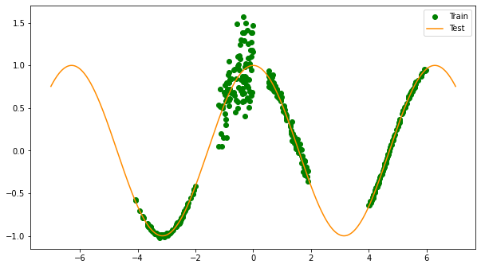

```python
# ========================= DATA VISUALIZATION =========================

fig, ax = plt.subplots(figsize=small_figsize)
ax.scatter(x_train.squeeze(), y_train, color="green", label="Train")
ax.plot(x_test.squeeze(), y_test, color="darkorange", label="Test")
plt.legend()
```

## 2. Hyperparameters

### 2.0 Neptune Logging

```python
# ============================================= NEPTUNE LOGGING ==========================================================

monitor = True # log to neptune? install + put api key in file as described in preprocessing.init_neptune
neptune_user = "halcyon"
neptune_project = "bnn-synthetic"

if monitor:
    import neptune.new as neptune
    from preprocessing import init_neptune
```

### 2.1 Inference: Variational Bayesian or MCMC?

```python
# ========================= INFERENCE SETTINGS =========================
inference = "svi" # 'mcmc', 'svi', "mle", "map"
variational_infs = {"svi", "mle", "map"}

# -------------- hyperparameters that are independent of the kind of inference ----------
reparameterize = True # will not be done for MCMC prediction
heteroskedastic = True # use an architecture that also learns a data dependent standard deviation? Otherwise use same standard deviation everywhere.
n_test_samples = 3 # samples drawn for visualisation
```

### 2.2 Architecture

We use a simple feedforward architecture with a `Tanh()` nonlinearity in all experiments.

It is however dependent on the kind of likelihood we chose:

- **Homoskedastic**: Let the network only learn an `x`-dependent mean, and train a non-`x`-dependent standard deviation outside of the PyTorch network.
- **Heteroskedastic**: Let the network learn both `x`-dependent mean and standard deviation.

```python
# ========================= NETWORK DEFINITION =========================

class FF(nn.Module):
    def __init__(self, dim=50, heteroskedastic=False, min_scale=1e-4):
        """
        >>> net = FF()  # corresponds to:
        >>> net = nn.Sequential(nn.Linear(1, 50), nn.Tanh(), nn.Linear(50, 1))
        """
        super().__init__()

        self.fc1 = nn.Linear(1, dim)
        self.tanh = nn.Tanh()

        self.loc_head = nn.Linear(dim, 1)

        self.heteroskedastic = heteroskedastic
        if self.heteroskedastic:
            self.scale_head = nn.Linear(dim, 1)
            # NOTE: used to constrain variance to be > 0 and possibly smaller than some value
            self.scale_nonlinearity = lambda s: s.clamp(min=1e-6, max=max_likelihood_scale)
            self.min_scale = min_scale
```

```python
    def forward(self, x):

        x = self.fc1(x)
        x = self.tanh(x)

        mean = self.loc_head(x)

        if not self.heteroskedastic:
            return mean
        else:
            scale = self.scale_head(x)
            scale = self.scale_nonlinearity(scale)
            # tyxe.likelihoods.HeteroskedasticGaussian expects network output to be
            # a concatenation of mean (no constraint) and scale (> 0) along last (hidden) dimension
            mean_scale = torch.cat([mean, scale], dim=-1) # N x B x 2D
            return mean_scale

FF.forward = forward
```

```python
# ========================= NETWORK SETUP =========================

hidden_dim = 50
net: nn.Module = FF(
    dim=hidden_dim,
    heteroskedastic=heteroskedastic
)
net = net.to(device=device)
```

### 2.3 More Inference specific Hyperparameters

The following hyperparameters are either specific to only

- either SVI or MCMC
- either a homoskedastic or a heteroskedastic likelihood

```python
# --------------- hyperparameters that are for variational_infs only -------------------
lr = 1e-2
epochs = 2000

mean_field = True # SVI only: recommend leaving True; full cov is compute intensive and often collapses; diagonal gauss suffices
elbo_samples = 1 # SVI only: recommend 1; num samples of weights to estimate the elbo per train batch
jit = False # SVI only: recommend leaving False, no impact on performance, but more compute intensive

# --------------- parameter constraints -------------------
# Guide
guide_init_scale = 1e-4 # SVI only: initial std of normal weights
guide_init_loc_range = 8e-3 # SVI only: boundary of uniform distribution around 0 used to init weight means
max_guide_scale = 2.0 # SVI only: used for both net guide and likelihood guide (in case of homoskedastic)

# Likelihood
train_likelihood_scale = True and not heteroskedastic # guide parameter (scale) of the homoskedastic likelihood? Else it is fixed.
likelihood_init_scale = 1e-2 # only applies to homoskedastic
max_likelihood_scale = 999999 # only applies to heteroskedastic (clamped in network output)
```

```python
# --------------- SVI only: KL annealing ----------------
do_kl_annealing = True # slow switch from ~= MLE to SVI, linear schedule
warmup_fraction = 0.05 # fraction of epochs at the start where ~= MLE is done
full_fraction = 0.05 # fraction of epochs at the end where full SVI is done

# --------------- MCMC exclusive -----------------
mcmc_samples = 32 # num samples for MCMC
mcmc_warmup = 32 # num warmup samples for MCMC

# how frequently the live figure is updated and metrics are logged to neptune
valid_freq = 50 if inference != "mcmc" else 1 # every logging frequency epochs/steps, plot some predictions on test data
```

## 4 Running the Experiment

```python
# =================  RUN TRAINING =================

print(f"Running {inference} on {device} for {train_duration} {duration_unit} ...")
with train_ctxt():
    bnn.fit(*fit_args, **fit_kwargs)
```

```
Running svi on cuda for 2000 epochs ...
```

**This is what the progress could look like during inference:**

[figure not shown]

# 5 Experiment Results

### 5.1 Individual Samples

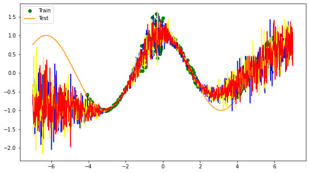

```python
# Final plot of n samples, separately
fig, ax = plt.subplots(figsize=small_figsize)
plot(
    bnn, n_test_samples, aggregate=False, data_tuple=data_tuple, fig=fig, valid_ctxt=valid_ctxt, device=device
)
if monitor:
    n_run["img/test_samples"].upload(neptune.types.File.as_image(fig))
```

### 5.1 Aggregated Samples

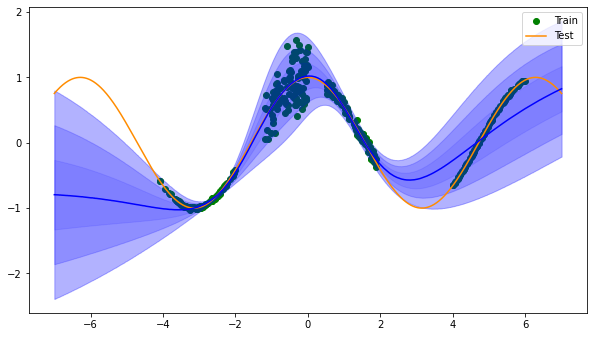

```python
# Final plot of n samples, aggregated
fig, ax = plt.subplots(figsize=small_figsize)
plot(
    bnn, n_test_samples, aggregate=True, data_tuple=data_tuple, fig=fig, valid_ctxt=valid_ctxt, device=device
)
if monitor:
    n_run["img/test_aggregate"].upload(neptune.types.File.as_image(fig))
```

## Your turn!

Play around with the hyperparameters.

See how the following impact the two types of uncertainty:

1. Add or remove a cluster.
2. Alter the spread of a cluster.
3. Try using a different function of $x$, like `x.pow(3)/350`
4. Try a homoskedastic likelihood.
5. Change the parameter constraints, e.g. `max_likelihood_scale'.
6. Compare with `inference = 'mcmc'`.

Things to keep in mind when experimenting:

- SVI is finnicky, and training collapses easily.
- Compare to a deterministic baseline using `inference = 'mle'`

# 6 References

- Intro to Aleatoric & Epistemic Uncertainties: [Hüllermeier & Wagemann (2020)](https://link.springer.com/article/10.1007/s10994-021-05946-3)
- How to model Alea. & Epis. Uncertainty using BNNs: [Depeweg et al. (2018)](http://proceedings.mlr.press/v80/depeweg18a.html?ref=https://githubhelp.com)
- TyXe [Repo](https://github.com/TyXe-BDL/TyXe/) | [Paper](https://proceedings.mlsys.org/paper/2022/hash/8d5e957f297893487bd98fa830fa6413-Abstract.html) | [Altered Repo](https://github.com/marvosyntactical/TyXe)
- This talk: [Slides](https://marvosyntactical.github.io) | [Repo](https://cegit.ziti.uni-heidelberg.de/comet/pyro-bnns/-/tree/main/Marvins-BNN-Inference-Experiments)

**Thank you for participating!**